# housing

- Assignment 2
- Part A: Regression
- Submitted by : Wang Jing 1841341

```python
# Suppress Future Warnings
import warnings
warnings.simplefilter(action='ignore', category=FutureWarning)
warnings.filterwarnings('ignore')
```

# Data Importing

```python
import sklearn
import numpy as np
import pandas as pd
import matplotlib
import platform
import re
from ggplot import *


message="        Versions        "
print("*"*len(message))
print(message)
print("*"*len(message))
print("Scikit-learn version={}".format(sklearn.__version__))
print("Numpy version={}".format(np.__version__))
print("Pandas version={}".format(pd.__version__))
print("Matplotlib version={}".format(matplotlib.__version__))
print("Python version={}".format(platform.python_version()))
print("Re version={}".format(re.__version__))
```

```
        Versions
Scikit-learn version=0.20.3
Numpy version=1.16.2
Pandas version=0.23.4
Matplotlib version=3.0.0
Python version=3.6.6
Re version=2.2.1
```

```python
from sklearn import datasets
from matplotlib import pyplot as plt
from mpl_toolkits.mplot3d import Axes3D
import seaborn as sns
%matplotlib inline
```

```python
# Algorithms
from sklearn import linear_model
from sklearn.linear_model import LogisticRegression
from sklearn.linear_model import Perceptron
from sklearn.linear_model import LinearRegression
from sklearn.ensemble import RandomForestRegressor
from sklearn.ensemble import GradientBoostingRegressor
from sklearn import ensemble, tree, linear_model
from sklearn.dummy import DummyRegressor
from sklearn.neighbors import KNeighborsRegressor
from sklearn.metrics import r2_score
from sklearn.metrics import mean_squared_error
```

```python
house = pd.read_csv("kc_house_data.csv")
house.head(5)
```

|  | id | date | price | bedrooms | bathrooms | sqft_living | sqft_lot | floors | waterfront | view | ... | grade | sqft_above | sqft_basement | yr_built | yr_renovated | zipcode | lat | long | sqft_living15 | sqft_lot15 |
| --- | --- | --- | --- | --- | --- | --- | --- | --- | --- | --- | --- | --- | --- | --- | --- | --- | --- | --- | --- | --- | --- |
| 0 | 7129300520 | 20141013T000000 | 221900.0 | 3 | 1.00 | 1180 | 5650 | 1.0 | 0 | 0 | ... | 7 | 1180 | 0 | 1955 | 0 | 98178 | 47.5112 | -122.257 | 1340 | 5650 |
| 1 | 6414100192 | 20141209T000000 | 538000.0 | 3 | 2.25 | 2570 | 7242 | 2.0 | 0 | 0 | ... | 7 | 2170 | 400 | 1951 | 1991 | 98125 | 47.7210 | -122.319 | 1690 | 7639 |
| 2 | 5631500400 | 20150225T000000 | 180000.0 | 2 | 1.00 | 770 | 10000 | 1.0 | 0 | 0 | ... | 6 | 770 | 0 | 1933 | 0 | 98028 | 47.7379 | -122.233 | 2720 | 8062 |
| 3 | 2487200875 | 20141209T000000 | 604000.0 | 4 | 3.00 | 1960 | 5000 | 1.0 | 0 | 0 | ... | 7 | 1050 | 910 | 1965 | 0 | 98136 | 47.5208 | -122.393 | 1360 | 5000 |
| 4 | 1954400510 | 20150218T000000 | 510000.0 | 3 | 2.00 | 1680 | 8080 | 1.0 | 0 | 0 | ... | 8 | 1680 | 0 | 1987 | 0 | 98074 | 47.6168 | -122.045 | 1800 | 7503 |

5 rows × 21 columns

# Data Analysis

```python
#Check basic data info
house.info()
```

```
<class 'pandas.core.frame.DataFrame'>
RangeIndex: 21613 entries, 0 to 21612
Data columns (total 21 columns):
id               21613 non-null int64
date             21613 non-null object
price            21613 non-null float64
bedrooms         21613 non-null int64
bathrooms        21613 non-null float64
sqft_living      21613 non-null int64
sqft_lot         21613 non-null int64
floors           21613 non-null float64
waterfront       21613 non-null int64
view             21613 non-null int64
condition        21613 non-null int64
grade            21613 non-null int64
sqft_above       21613 non-null int64
sqft_basement    21613 non-null int64
yr_built         21613 non-null int64
yr_renovated     21613 non-null int64
zipcode          21613 non-null int64
lat              21613 non-null float64
long             21613 non-null float64
sqft_living15    21613 non-null int64
sqft_lot15       21613 non-null int64
dtypes: float64(5), int64(15), object(1)
memory usage: 3.5+ MB
```

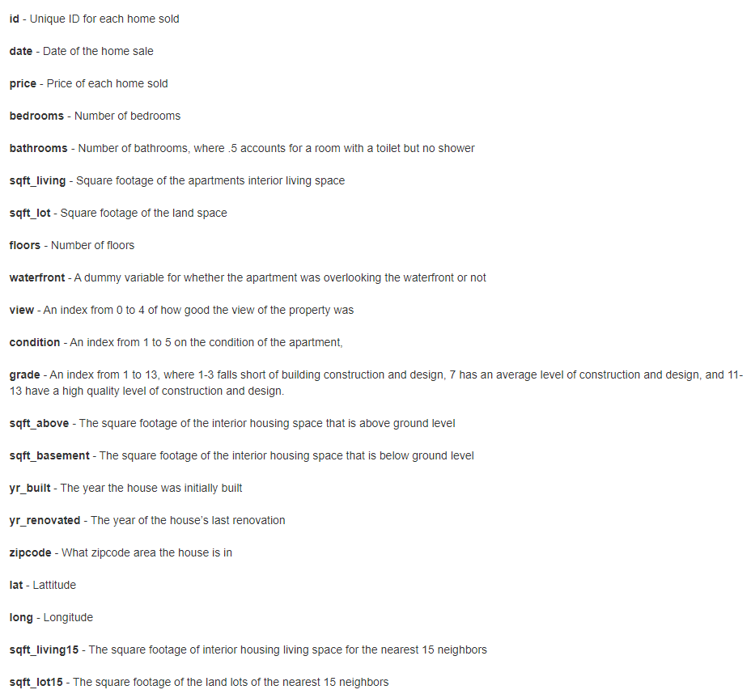

```python
# Column definitions
from IPython.display import Image
Image(filename='features.png')
```

```python
# List out all variables with nulls/missing values
print(house.isna().sum())
```

```
id               0
date             0
price            0
bedrooms         0
bathrooms        0
sqft_living      0
sqft_lot         0
floors           0
waterfront       0
view             0
condition        0
grade            0
sqft_above       0
sqft_basement    0
yr_built         0
yr_renovated     0
zipcode          0
lat              0
long             0
sqft_living15    0
sqft_lot15       0
dtype: int64
```

```python
#List out all varibles with unique values
house.nunique()
```

```
id               21436
date               372
price             4028
bedrooms            13
bathrooms           30
sqft_living       1038
sqft_lot          9782
floors               6
waterfront           2
view                 5
condition            5
grade               12
sqft_above         946
sqft_basement      306
yr_built           116
yr_renovated        70
zipcode             70
lat               5034
long               752
sqft_living15      777
sqft_lot15        8689
dtype: int64
```

```python
# Get list of numeric and nonnumeric variables
numvars = list(house.columns[house.dtypes != "object"])
nonnumvars = list(house.columns[house.dtypes == "object"])
print(numvars)
print(nonnumvars)
```

```
['id', 'price', 'bedrooms', 'bathrooms', 'sqft_living', 'sqft_lot', 'floors', 'waterfront', 'view', 'condition', 'grade', 'sqft_above', 'sqft_basement', 'yr_built', 'yr_renovated', 'zipcode', 'lat', 'long', 'sqft_living15', 'sqft_lot15']
['date']
```

# Data Exploration

## id

```python
# id is redunant, lets drop it
house = house.drop('id', 1)
```

## price

```python
house['price'].describe()
```

```
count    2.161300e+04
mean     5.400881e+05
std      3.671272e+05
min      7.500000e+04
25%      3.219500e+05
50%      4.500000e+05
75%      6.450000e+05
max      7.700000e+06
Name: price, dtype: float64
```

```
Skewness: 4.024069
```

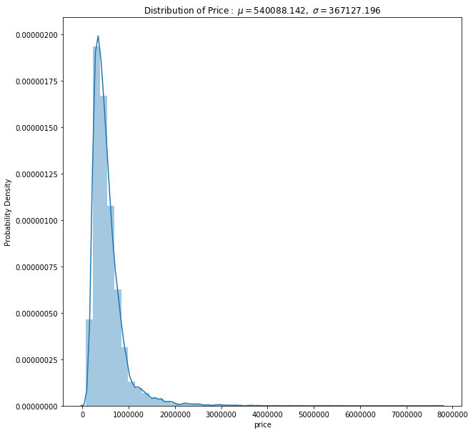

```python
mu = house['price'].mean()
sigma = house['price'].std()
plt.figure(figsize=(10,10))
plt.xlabel('House Price')
plt.ylabel('Probability Density')


plt.title(r'$\mathrm{Distribution\ of\ Price:}\ \mu=%.3f,\ \sigma=%.3f$'%(mu,sigma))
print("Skewness: %f" % house['price'].skew())
sns.distplot(house['price'] )
```

The mean value of homes of 540,088 is greater than the median of 450,000. This is an indication that the response variable is positively skewed (Skewness: 4.024069). When this happens, regressing the log of price usually provides a better fitting, compared to the original price.

Majority of the houses are priced below $2000000.

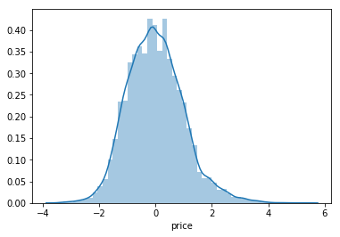

```python
# log the price
house["price"] = np.log(house["price"])
# get the mean for the log price
m=house.price.mean()
# get the standard deviation of the log price
std=house.price.std()

#scaling to get a log normal distribution
house.price = (house.price - m) / std
sns.distplot(house.price)
```

## bedrooms

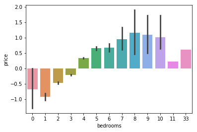

```python
sns.barplot(x='bedrooms', y='price', data=house)
```

Generally, as bedroom number increase, price increase.

```python
#Dropping the outlier with 33 bedrooms, I don't think the white house is in seattle.
house = house[house.bedrooms != 33]
```

```python
house['bedrooms'].value_counts()
```

```
3     9824
4     6882
2     2760
5     1601
6      272
1      199
7       38
8       13
0       13
9        6
10       3
11       1
Name: bedrooms, dtype: int64
```

Major of the houses have 3 or 4 bedrooms, and these houses have the smallest deviation in price too.